# Exercise 3: Plotting with ggplot2 + other useful packages

```r
library(readr)
library(dplyr)
library(RColorBrewer)
library(ComplexHeatmap)
library(ggplot2)
```

# Question 1

For this question, we will continue to use the *gapminder* dataset:

```r
gapminder <- read_csv(file = "data/gapminder-FiveYearData.csv")
```

Try to replicate the following plots. You will have to explore other options within the `geoms` and other elements like `theme`. Guide yourself with the material [here](http://ggplot2.tidyverse.org/reference/).

**Optional:** What plot would YOU make to visualise this dataset?

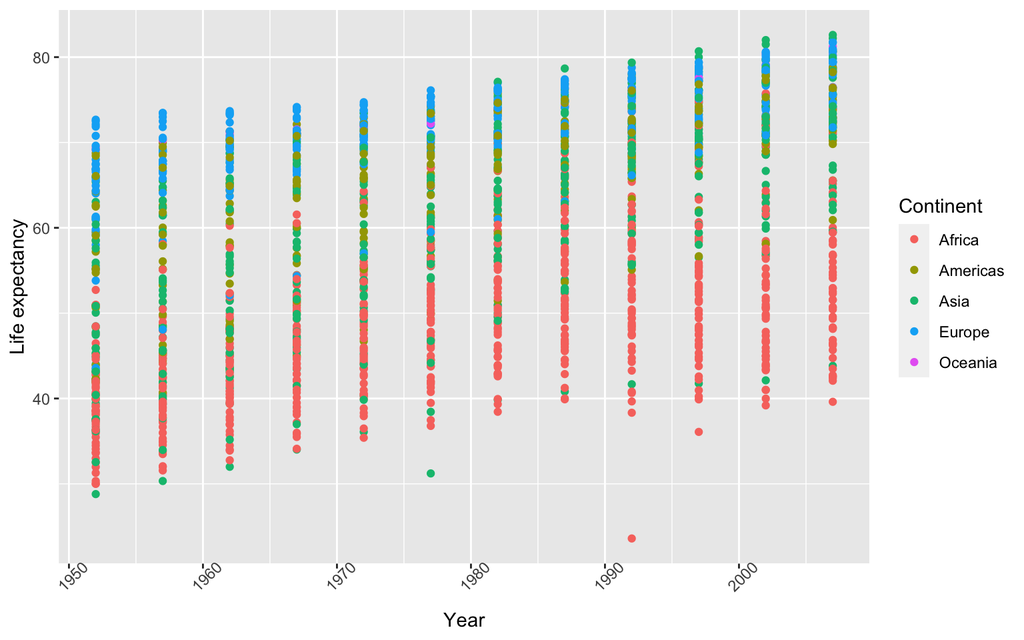

```r
p1 <- ggplot(data = gapminder, aes(x = year, y = lifeExp, colour = continent)) +
  geom_point() +
  theme(axis.text.x = element_text(angle = 45)) +
  labs(x = "Year",
    y = "Life expectancy",
    colour = "Continent")
p1
```

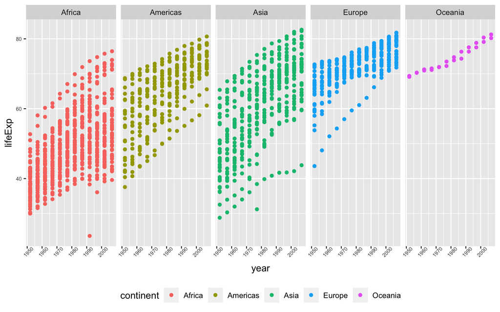

```r
p2 <- ggplot(data = gapminder, aes(x = year, y = lifeExp, colour = continent)) +
  geom_point() +
  theme(legend.position = "bottom", axis.text=element_text(size=6),
        axis.text.x = element_text(angle = 45)) +
  facet_grid(~continent)

p2
```

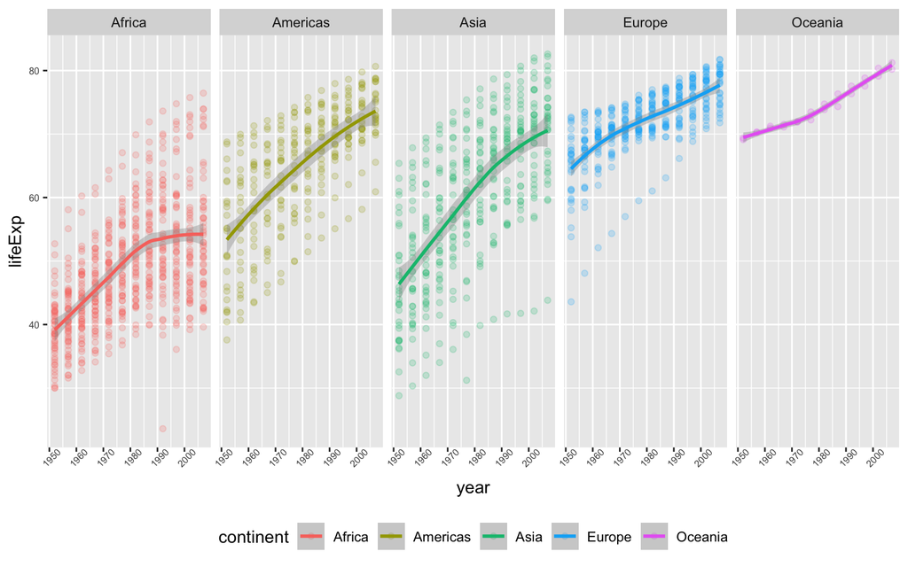

```r
p3 <- ggplot(data = gapminder, aes(x = year, y = lifeExp, colour = continent)) +
  geom_point(alpha = 0.2) +
  geom_smooth() +
  theme(legend.position = "bottom", axis.text=element_text(size=6),
        axis.text.x = element_text(angle = 45)) +
  facet_grid(~continent)
p3
```

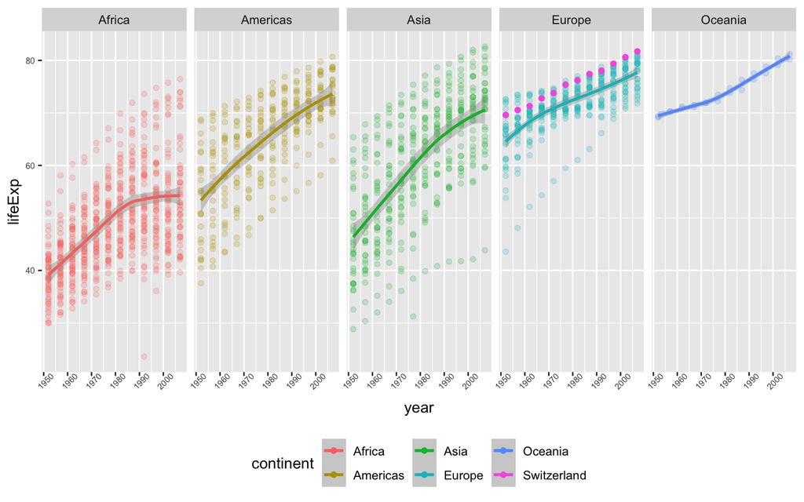

```r
swiss <- gapminder %>% filter(country == "Switzerland")

p4 <- ggplot(data = gapminder, aes(x = year, y = lifeExp, colour = continent)) +
  geom_point(alpha = 0.2) +
  geom_smooth() +
  theme(legend.position = "bottom", axis.text=element_text(size=6),
        axis.text.x = element_text(angle = 45)) +
  geom_point(data = swiss, aes(x = year, y = lifeExp, colour = country)) +
  facet_grid(~continent)
p4
```

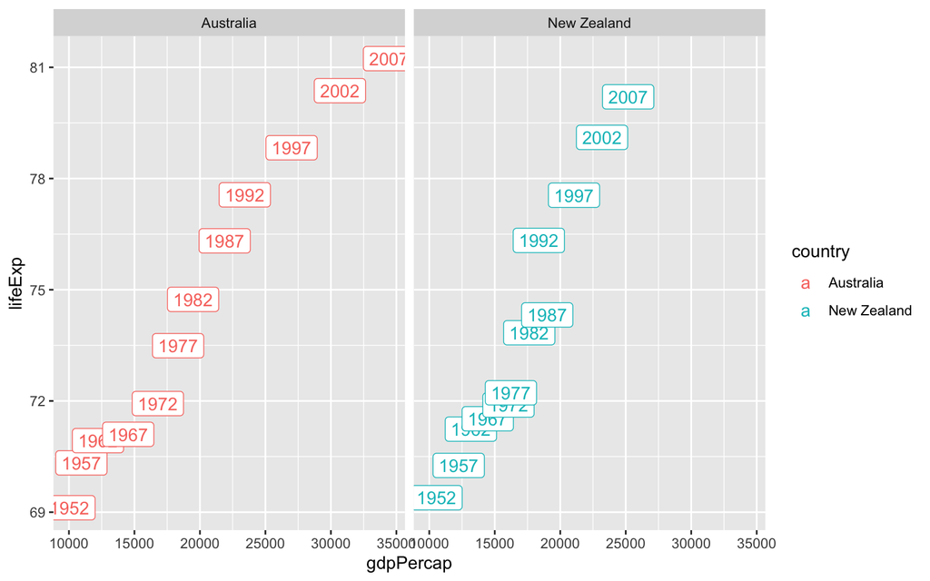

```r
oceania <- gapminder %>% filter(continent == "Oceania")

p5 <- ggplot(data = oceania, aes(x = gdpPercap, y = lifeExp, colour = country)) +
  geom_point() +
  facet_grid(~country) +
  geom_label(aes(label = year))

p5
```

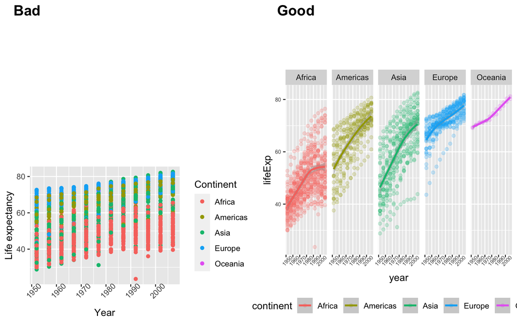

```r
library(cowplot)

ggdraw() +
  draw_plot(p1, 0, 0, .5, .5) +
  draw_plot(p3, 0.5, 0, .5, 0.8) +
  draw_plot_label(c("Bad", "Good"), c(0, 0.5), c(1, 1))
```

# Question 2

For this part, you will create the **Heatmap** using the `airway` dataset used in the `data.frame` Exercise.

First load the data, which is ready for plotting (you DO NOT have to do anything to it!)

```r
load("data/airway_subset.RData")
```

This is the code we used to generate the data. We show it here in case you are interested.

```r
# library(airway)
# library(edgeR)
# library(dplyr)
# data("airway")
#
# sample_info <- airway %>%
#     colData() %>%
#     as.data.frame() %>%
#     rename(group = dex) %>%
#     rename(sample = Run) %>%
#     select(sample, group)
#
# # select a subset of data
# expr <- assay(airway)
# dge <- DGEList(counts = expr, samples = sample_info)
# dge <- calcNormFactors(dge, method = "TMM")
# dge <- estimateDisp(dge)
# fit <- glmFit(dge)
# results <- glmLRT(fit, coef=2)
# diffG <- rownames(topTags(results, n = 5))
# set.seed(1)
# sameG <- sample(setdiff(rownames(expr), diffG), 15)
#
# # select 5 DE + 15 non-DE
# sel <- sample(c(diffG, sameG))
# # CPM-counts are exported
# gene_counts  <- cpm(expr)[sel, ]
#
# save(gene_counts, sample_info, file = "data/airway_subset.RData")
```

We will use two tables: `sample_info` and `gene_counts`. Make sure you take a look at them before starting.

1. How many samples are in the `gene_counts`? How many genes are measured? How many samples are measured in each group?

```r
ncol(gene_counts) #8
```

```
## [1] 8
```

```r
nrow(gene_counts) #20
```

```
## [1] 20
```

```r
table(sample_info$group) #4
```

```
##
##   trt untrt
##     4     4
```

2. Create a simple heatmap to visualize the data.

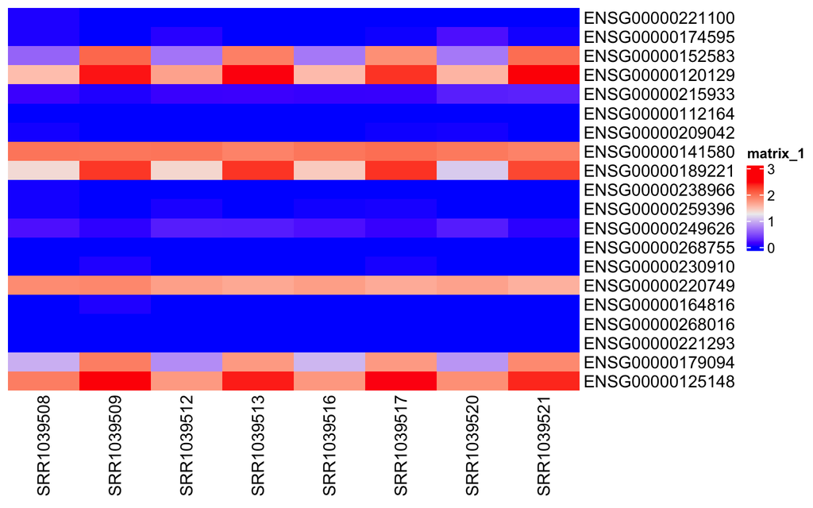

```r
gene_counts <- log10(gene_counts+1)
Heatmap(gene_counts, cluster_rows = FALSE, cluster_columns = FALSE)
```

3. Improve the heatmap. For example, adjust the size of the gene names, annotate the samples, hide the column dendrogram, or use other colors…(Use a nice color palette from [brewer.pal](https://www.r-bloggers.com/2015/04/create-colorful-graphs-in-r-with-rcolorbrewer-and-plotly/))

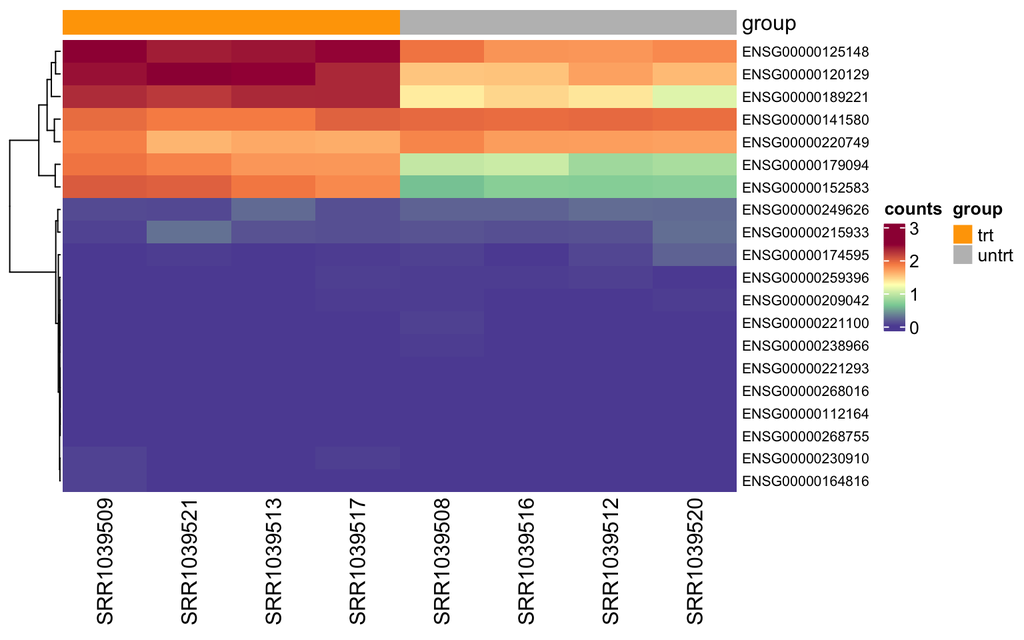

```r
groupAnno <- sample_info$group
names(groupAnno) <- sample_info$sample
ha <- HeatmapAnnotation(group = groupAnno,
                        col = list(group = c("untrt" = "grey", "trt" = "orange")))
Heatmap(gene_counts, name = "counts", row_names_gp = gpar(fontsize = 8),
        show_column_dend = FALSE,
        top_annotation = ha, col= colorRampPalette(rev(brewer.pal(n = 11, name = "Spectral")))(5))
```

4. Do you see difference between groups from the heatmap? Provide at least one gene that has different levels between groups.

```r
#"ENSG00000152583" "ENSG00000179094" "ENSG00000120129" "ENSG00000189221" "ENSG00000125148"
```

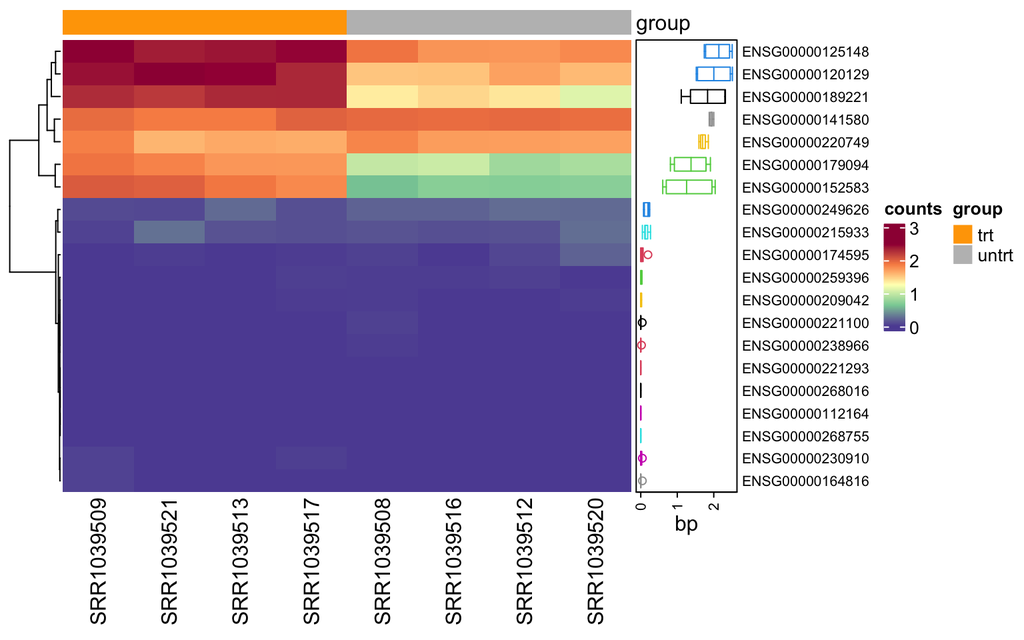

```r
ha2 <- rowAnnotation(bp = anno_boxplot(gene_counts, gp = gpar(col = 1:nrow(gene_counts))))
Heatmap(gene_counts, right_annotation = ha2,
        show_column_dend = FALSE,
        name = "counts", row_names_gp = gpar(fontsize = 8),
        top_annotation = ha, col= colorRampPalette(rev(brewer.pal(n = 11, name = "Spectral")))(5))
```

If you want to play around more, you can look for [more ideas](https://jokergoo.github.io/ComplexHeatmap-reference/book/more-examples.html), and customize your Heatmap until you are happy with it.